# Fate of soil nitrogen under long-term bare fallow - supplementry

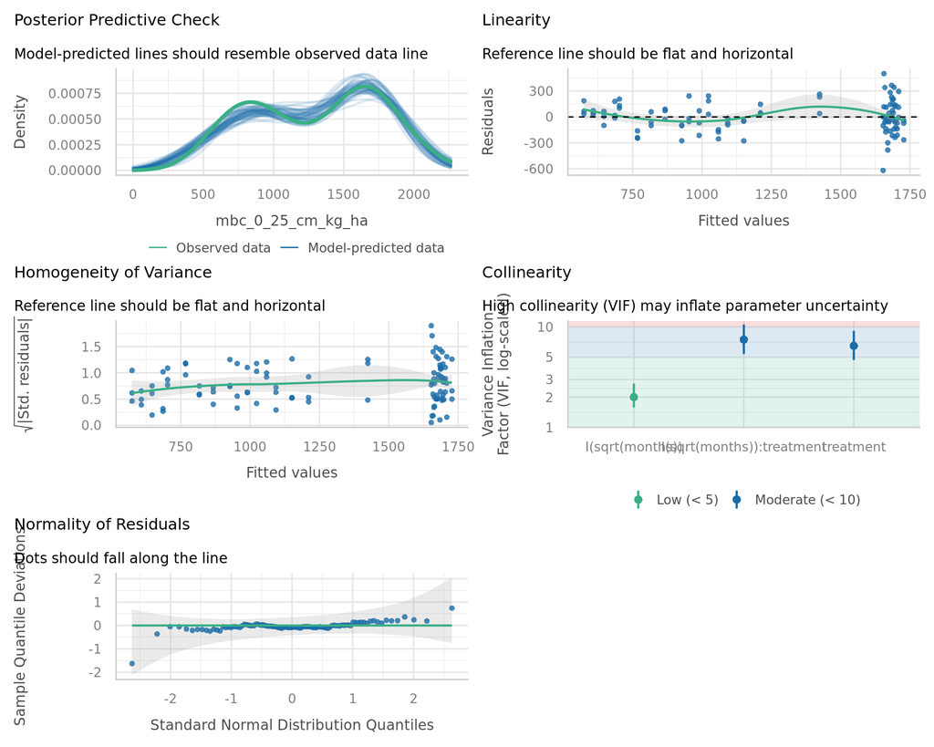

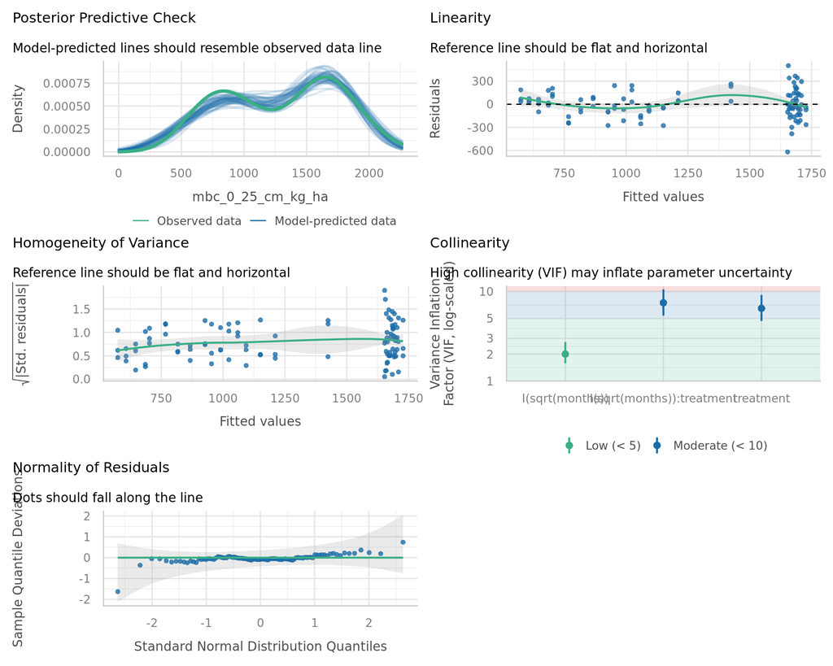

```
 ============================================================
 Response: mbn_kg_ha | Best model: Square Root
============================================================
```

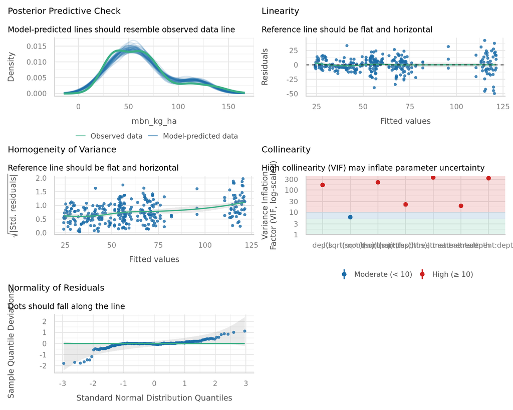

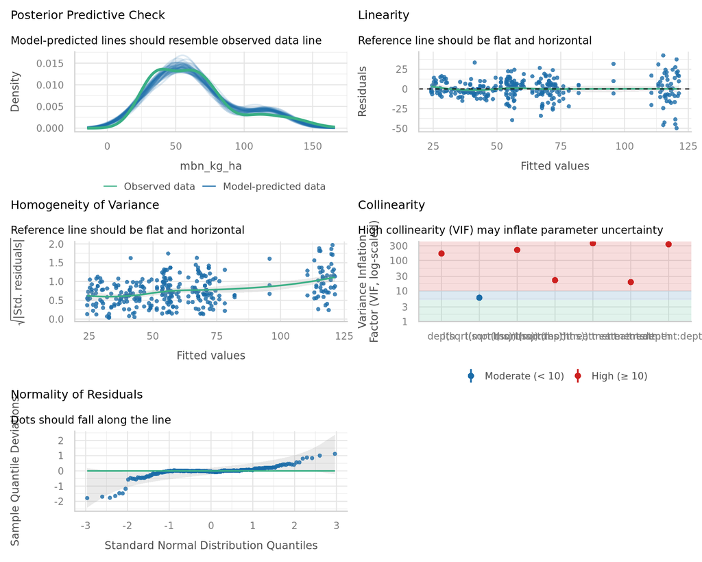

```
 ============================================================
 Response: mbn_0_25_cm_kg_ha | Best model: Square Root
============================================================
```

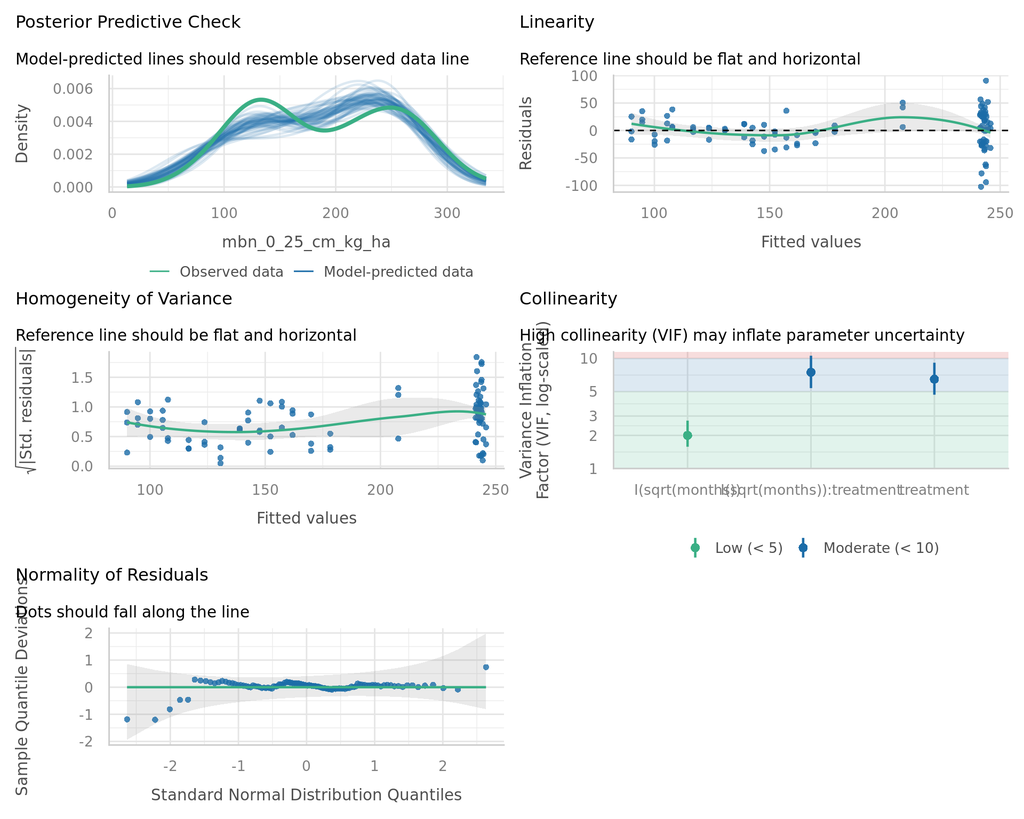

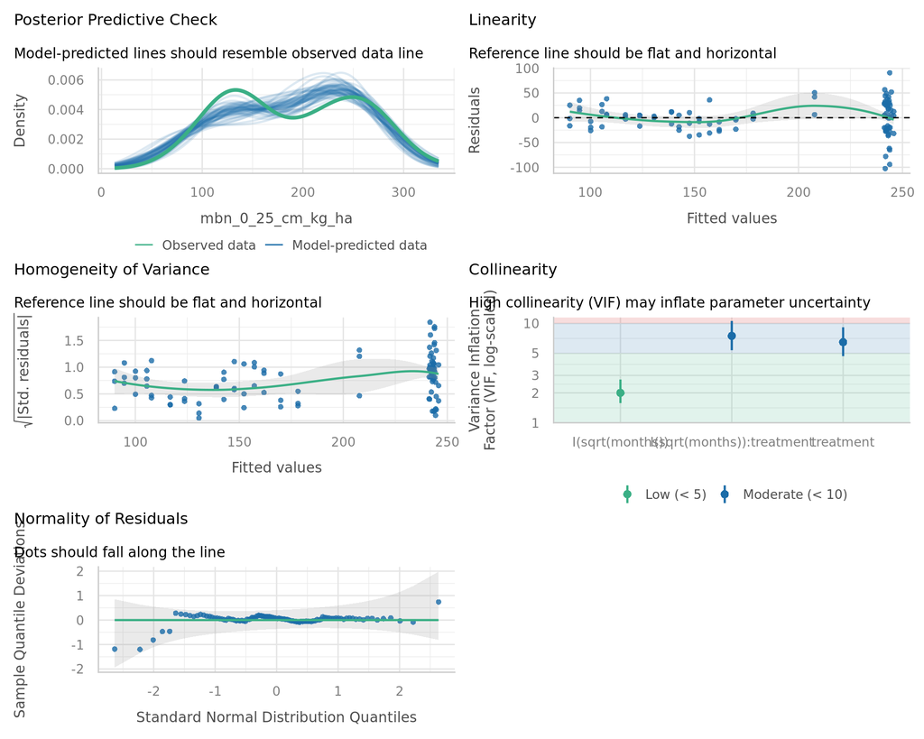

**Best model summaries (click to show/hide)**

```
======================================================================
  Response variable: mbc_mg_kg
  Best model:        Square Root
======================================================================


Call:
lm(formula = f, data = d)

Residuals:
    Min      1Q  Median      3Q     Max
-375.56  -36.16   -2.90   34.53  519.20

Coefficients:
                                              Estimate Std. Error t value
(Intercept)                                    688.678     28.619  24.064
I(sqrt(months))                                -35.940      3.520 -10.211
treatmentPasture                               233.969     40.473   5.781
depth150-250                                  -431.480     40.473 -10.661
depth75-150                                   -267.340     40.473  -6.605
I(sqrt(months)):treatmentPasture                33.675      4.977   6.766
I(sqrt(months)):depth150-250                    21.865      4.977   4.393
I(sqrt(months)):depth75-150                     13.434      4.977   2.699
treatmentPasture:depth150-250                 -202.842     57.238  -3.544
treatmentPasture:depth75-150                  -152.447     57.238  -2.663
I(sqrt(months)):treatmentPasture:depth150-250  -20.692      7.039  -2.940
I(sqrt(months)):treatmentPasture:depth75-150   -13.395      7.039  -1.903
                                              Pr(>|t|)
(Intercept)                                    < 2e-16 ***
I(sqrt(months))                                < 2e-16 ***
treatmentPasture                              1.90e-08 ***
depth150-250                                   < 2e-16 ***
depth75-150                                   1.86e-10 ***
I(sqrt(months)):treatmentPasture              7.18e-11 ***
I(sqrt(months)):depth150-250                  1.56e-05 ***
I(sqrt(months)):depth75-150                   0.007359 **
treatmentPasture:depth150-250                 0.000459 ***
treatmentPasture:depth75-150                  0.008162 **
I(sqrt(months)):treatmentPasture:depth150-250 0.003548 **
I(sqrt(months)):treatmentPasture:depth75-150  0.058020 .
```

[output cut: 194 more lines]

```
     Min       1Q   Median       3Q      Max
-102.557  -19.631    1.364   18.479   90.805

Coefficients:
                                 Estimate Std. Error t value Pr(>|t|)
(Intercept)                       210.885     11.056  19.075  < 2e-16 ***
I(sqrt(months))                    -9.907      1.360  -7.286 8.17e-11 ***
treatmentPasture                   35.030     15.635   2.241   0.0273 *
I(sqrt(months)):treatmentPasture    9.529      1.923   4.956 3.02e-06 ***
---
Signif. codes:  0 '***' 0.001 '**' 0.01 '*' 0.05 '.' 0.1 ' ' 1

Residual standard error: 31.01 on 98 degrees of freedom
Multiple R-squared:  0.7826,    Adjusted R-squared:  0.7759
F-statistic: 117.6 on 3 and 98 DF,  p-value: < 2.2e-16
```

### Soil pH and cations

**Plots**

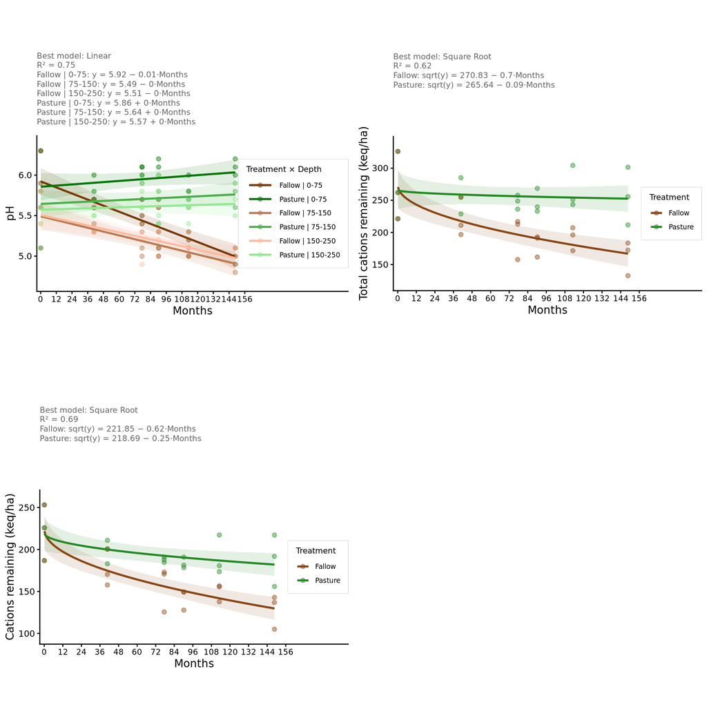

**AICc table**

| Response/Hypothesis | Model | K | n | R2 | AICc | Δi | ωi | Evid. ratio | Model Formula |
| --- | --- | --- | --- | --- | --- | --- | --- | --- | --- |
| p_h | Linear | 13 | 108 | 0.75 | -34.9 | 0.0 | 0.78 | 1.00 | months × treatment × depth |
|  | Square Root | 13 | 108 | 0.75 | -32.3 | 2.6 | 0.21 | 3.68 | sqrt(months) × treatment × depth |
|  | Quadratic | 19 | 108 | 0.77 | -23.0 | 11.9 | 0.00 | 388.26 | months² × treatment × depth |
| cations_0_25_cm_keq_ha | Square Root | 5 | 36 | 0.62 | 354.3 | 0.0 | 0.69 | 1.00 | sqrt(months) × treatment |
|  | Linear | 5 | 36 | 0.60 | 356.2 | 1.9 | 0.27 | 2.57 | months × treatment |
|  | Quadratic | 7 | 36 | 0.62 | 360.1 | 5.8 | 0.04 | 18.49 | months² × treatment |
| ca_0_25_cm_keq_ha | Square Root | 5 | 36 | 0.69 | 324.8 | 0.0 | 0.88 | 1.00 | sqrt(months) × treatment |
|  | Linear | 5 | 36 | 0.64 | 330.0 | 5.2 | 0.07 | 13.53 | months × treatment |
|  | Quadratic | 7 | 36 | 0.70 | 330.4 | 5.6 | 0.05 | 16.80 | months² × treatment |

**Model checks (click to show/hide)**

```
 ============================================================
 Response: p_h | Best model: Linear
============================================================
```

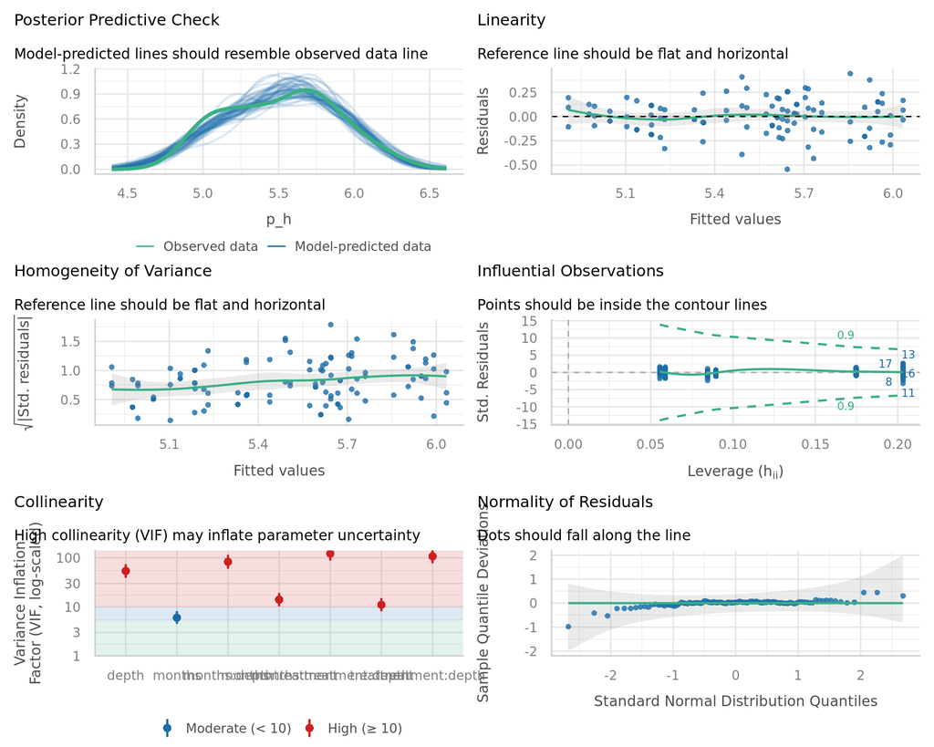

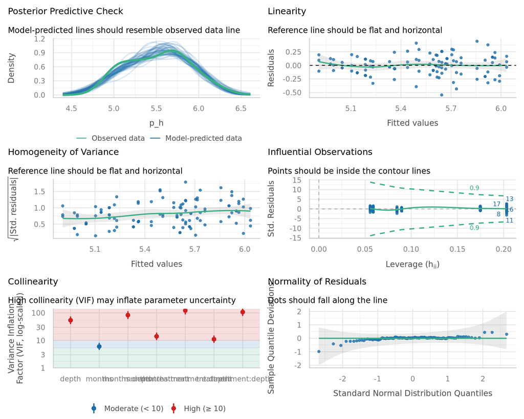

```
 ============================================================
 Response: cations_0_25_cm_keq_ha | Best model: Square Root
============================================================
```

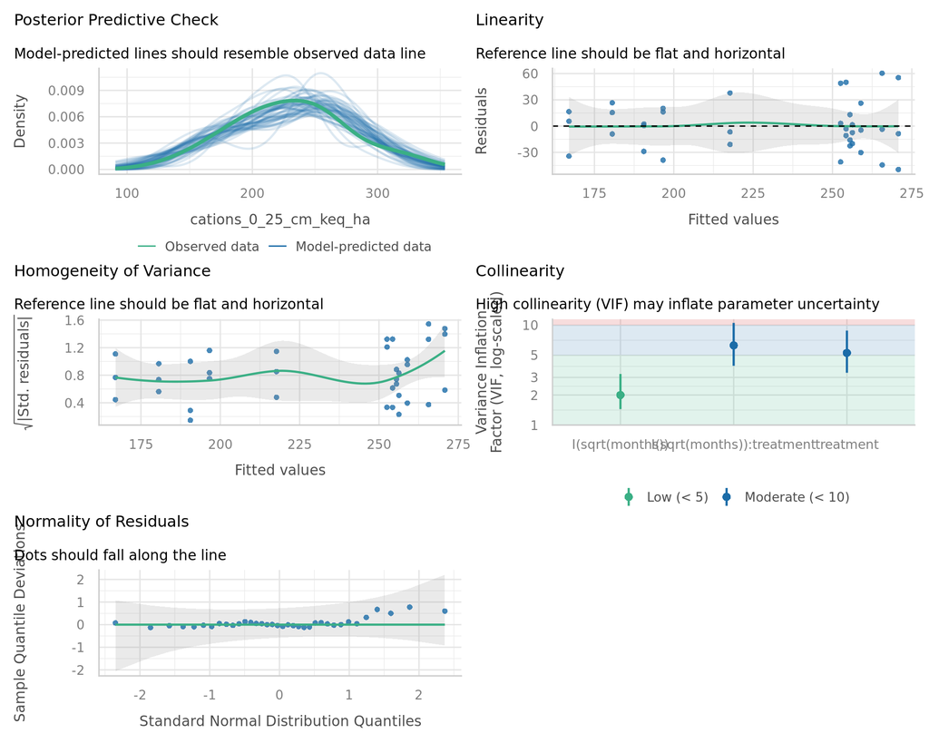

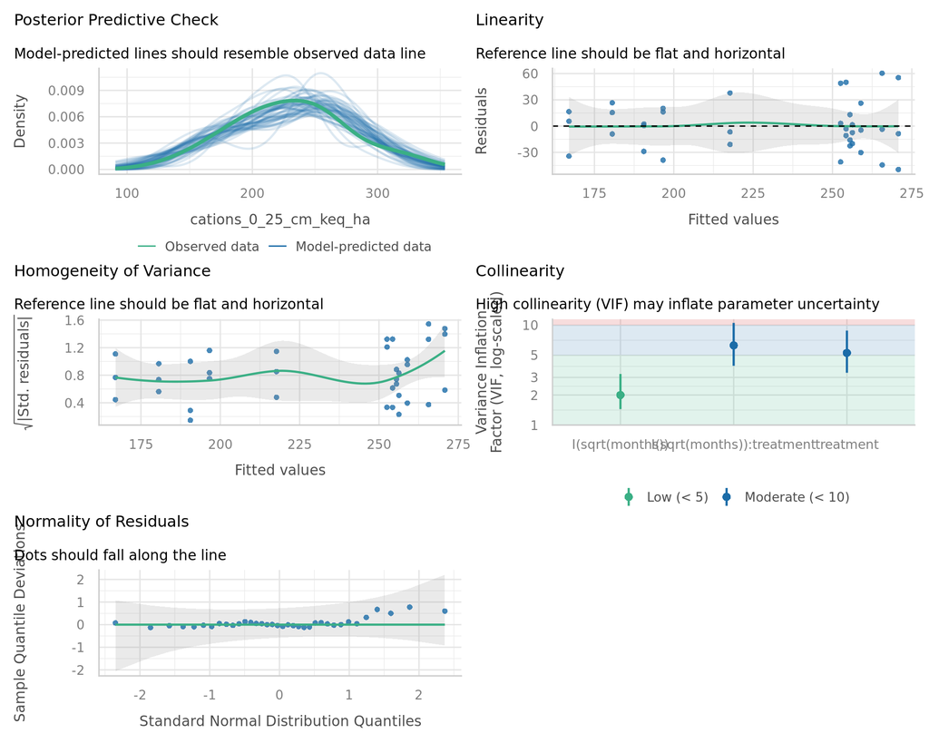

```
 ============================================================
 Response: ca_0_25_cm_keq_ha | Best model: Square Root
============================================================
```

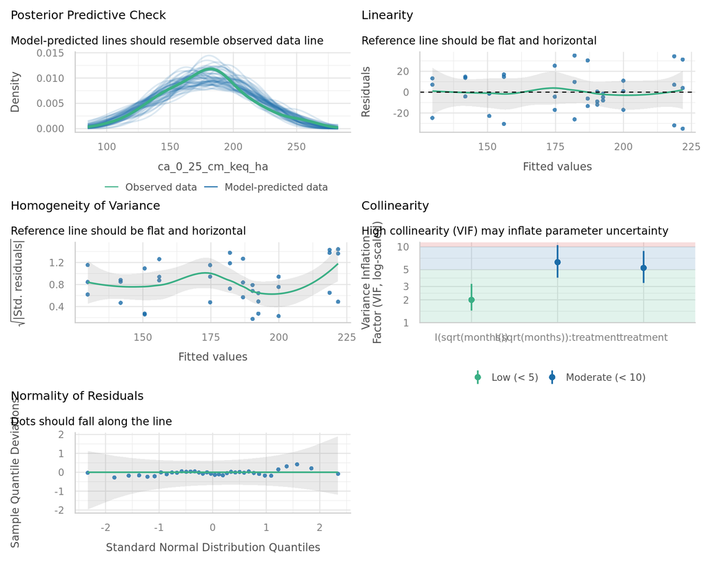

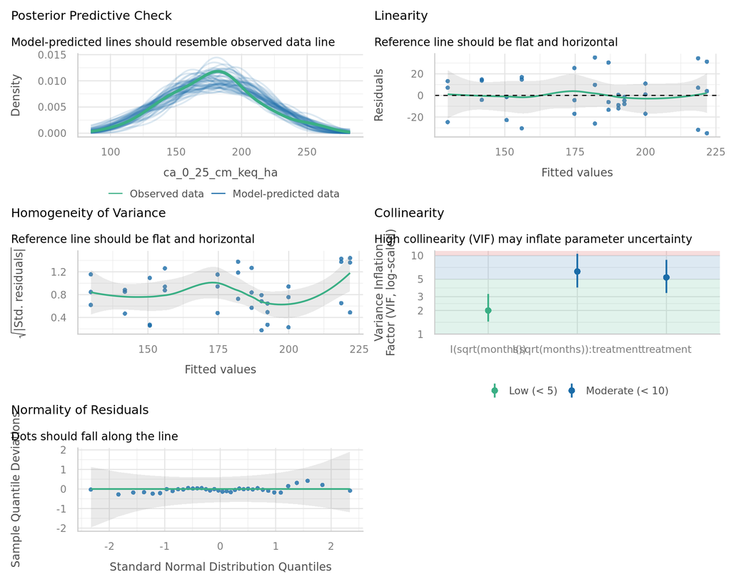

**Best model summaries (click to show/hide)**

```
======================================================================
  Response variable: p_h
  Best model:        Linear
======================================================================


Call:
lm(formula = f, data = d)

Residuals:
     Min       1Q   Median       3Q      Max
-0.54417 -0.10687  0.00701  0.11339  0.44360

Coefficients:
                                       Estimate Std. Error t value Pr(>|t|)
(Intercept)                           5.9224263  0.0858060  69.021  < 2e-16 ***
months                               -0.0062387  0.0009333  -6.684 1.53e-09 ***
treatmentPasture                     -0.0661459  0.1213480  -0.545 0.586954
depth150-250                         -0.4144539  0.1213480  -3.415 0.000935 ***
depth75-150                          -0.4306980  0.1213480  -3.549 0.000600 ***
months:treatmentPasture               0.0074342  0.0013200   5.632 1.77e-07 ***
months:depth150-250                   0.0026646  0.0013200   2.019 0.046303 *
months:depth75-150                    0.0023049  0.0013200   1.746 0.083972 .
treatmentPasture:depth150-250         0.1314403  0.1716120   0.766 0.445606
treatmentPasture:depth75-150          0.2185099  0.1716120   1.273 0.205994
months:treatmentPasture:depth150-250 -0.0033774  0.0018667  -1.809 0.073538 .
months:treatmentPasture:depth75-150  -0.0027164  0.0018667  -1.455 0.148881
---
Signif. codes:  0 '***' 0.001 '**' 0.01 '*' 0.05 '.' 0.1 ' ' 1

Residual standard error: 0.1901 on 96 degrees of freedom
Multiple R-squared:  0.7549,    Adjusted R-squared:  0.7268
F-statistic: 26.88 on 11 and 96 DF,  p-value: < 2.2e-16



======================================================================
  Response variable: cations_0_25_cm_keq_ha
  Best model:        Square Root
======================================================================
```

[output cut: 34 more lines]

```
    Min      1Q  Median      3Q     Max
-34.981 -12.325  -1.347  13.370  35.126

Coefficients:
                                 Estimate Std. Error t value Pr(>|t|)
(Intercept)                       224.240     10.709  20.940  < 2e-16 ***
I(sqrt(months))                    -7.751      1.209  -6.409 3.34e-07 ***
treatmentPasture                   -4.595     15.144  -0.303   0.7635
I(sqrt(months)):treatmentPasture    4.665      1.710   2.728   0.0103 *
---
Signif. codes:  0 '***' 0.001 '**' 0.01 '*' 0.05 '.' 0.1 ' ' 1

Residual standard error: 19.77 on 32 degrees of freedom
Multiple R-squared:  0.6925,    Adjusted R-squared:  0.6636
F-statistic: 24.02 on 3 and 32 DF,  p-value: 2.492e-08
```

### N Leached

Linear regression (`lm`): response ~ cumulative drainage × treatment. **Year-level** totals use the block from column AK. **Plot N Leached** (column AC, header row 8) uses the same **Months** time axis as the Mineral N analysis (via mean `months` per year from the Mineral N sheet). That sub-model uses **`lm(log(plot_n_leached) ~ …)`** (Gaussian errors on the log scale; rows with `plot_n_leached == 0` excluded). Fitted values and intervals are shown on the **original scale** (back-transformed).

#### Cumulative N leached (year totals)

**Plots**

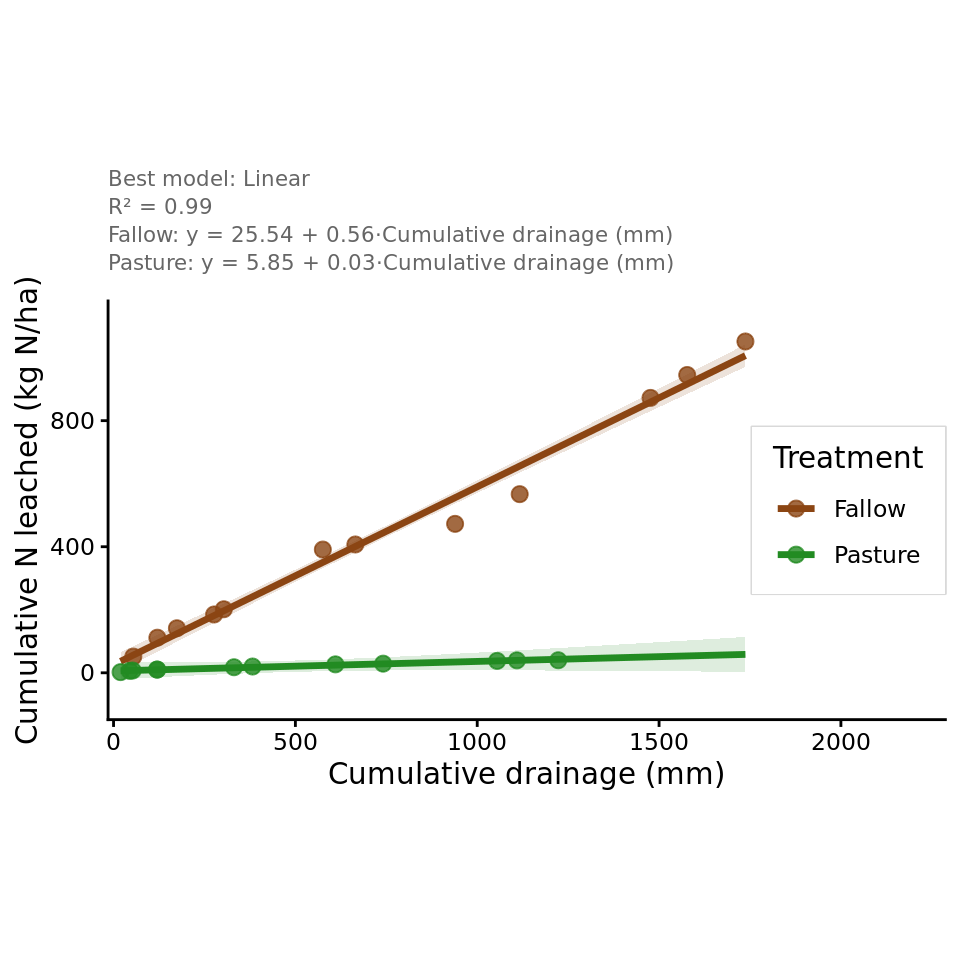

**Model checks (click to show/hide)**

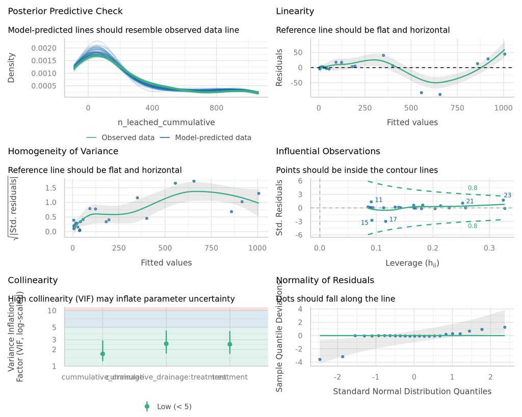

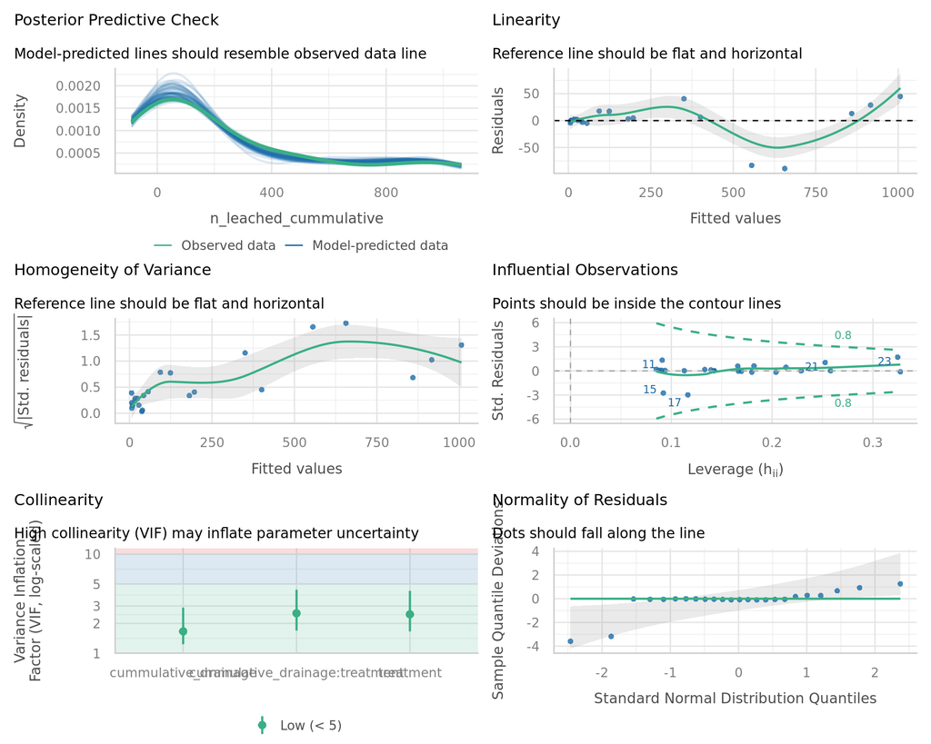

**Model summary and statistical significance**

```
Call:
lm(formula = n_leached_cummulative ~ cummulative_drainage * treatment,
    data = df.5)

Residuals:
    Min      1Q  Median      3Q     Max
-89.227  -0.499   1.217   7.964  44.811

Coefficients:
                                       Estimate Std. Error t value Pr(>|t|)
(Intercept)                            25.53649   15.06176   1.695    0.106
cummulative_drainage                    0.56457    0.01587  35.569  < 2e-16 ***
treatmentPasture                      -19.68396   20.43954  -0.963    0.347
cummulative_drainage:treatmentPasture  -0.53435    0.02656 -20.115 9.68e-15 ***
---
Signif. codes:  0 '***' 0.001 '**' 0.01 '*' 0.05 '.' 0.1 ' ' 1

Residual standard error: 31.87 on 20 degrees of freedom
Multiple R-squared:  0.9916,    Adjusted R-squared:  0.9903
F-statistic: 785.3 on 3 and 20 DF,  p-value: < 2.2e-16
```

#### Plot N Leached

**Plots**

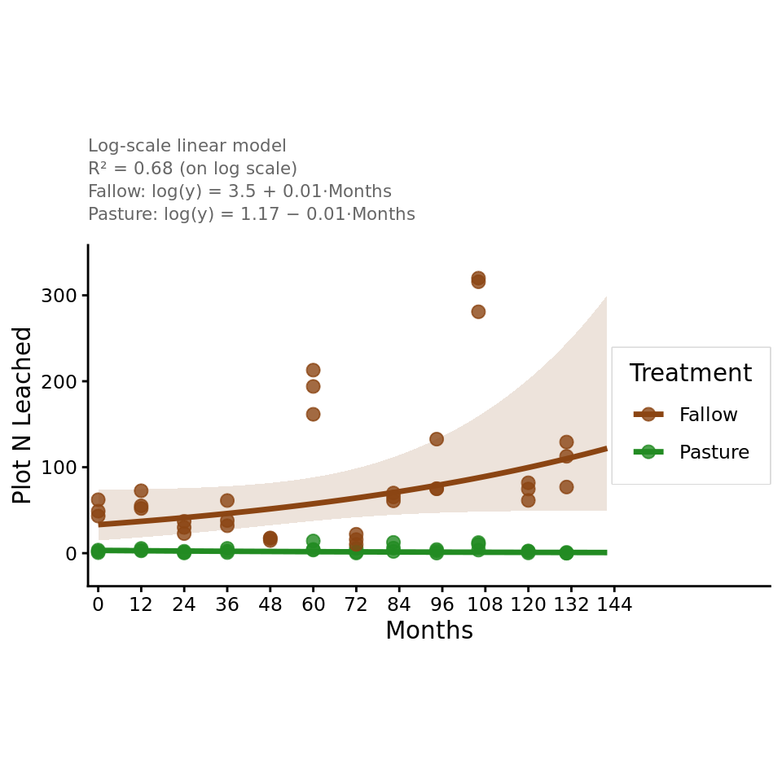

- A lognormal-style specification (`lm` on `log(response)`) is used **for this Plot N Leached model only**; other analyses in this report use models on the original response scale.

**Model checks (Plot N Leached; click to show/hide)**

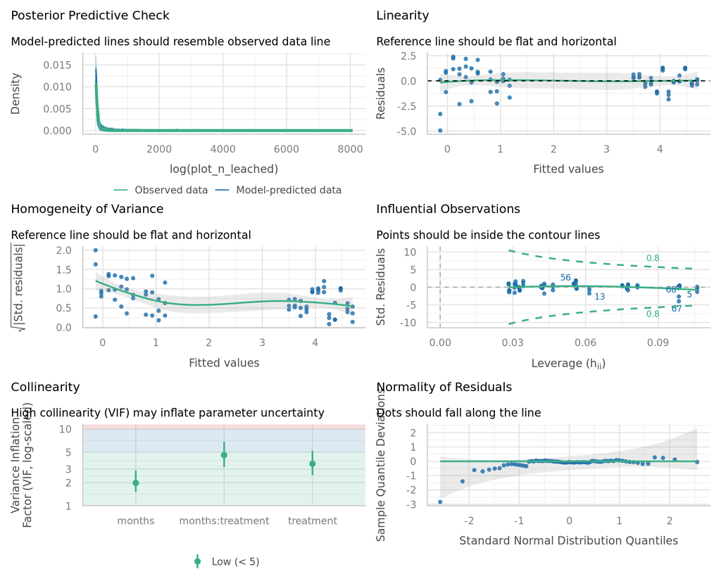

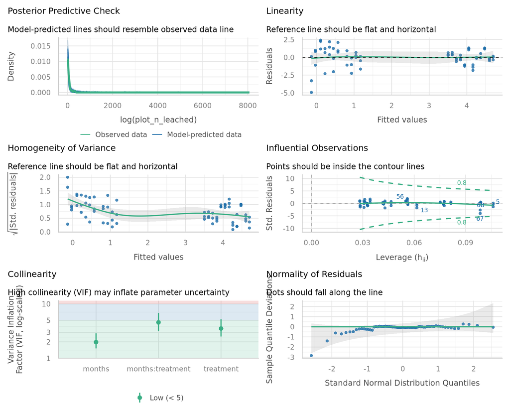

**Model summary (Plot N Leached; click to show/hide)**

```
Call:
lm(formula = log(plot_n_leached) ~ months * treatment, data = df.5.plot,
    subset = plot_n_leached > 0)

Residuals:
    Min      1Q  Median      3Q     Max
-4.9420 -0.4846  0.0971  0.8062  2.4066

Coefficients:
                         Estimate Std. Error t value Pr(>|t|)
(Intercept)              3.502560   0.408480   8.575 2.79e-12 ***
months                   0.009164   0.005291   1.732 0.088030 .
treatmentPasture        -2.331969   0.588199  -3.965 0.000186 ***
months:treatmentPasture -0.019161   0.007514  -2.550 0.013139 *
---
Signif. codes:  0 '***' 0.001 '**' 0.01 '*' 0.05 '.' 0.1 ' ' 1

Residual standard error: 1.3 on 65 degrees of freedom
Multiple R-squared:  0.681, Adjusted R-squared:  0.6663
F-statistic: 46.26 on 3 and 65 DF,  p-value: 4.02e-16
```

### Mineral N

**Plots**

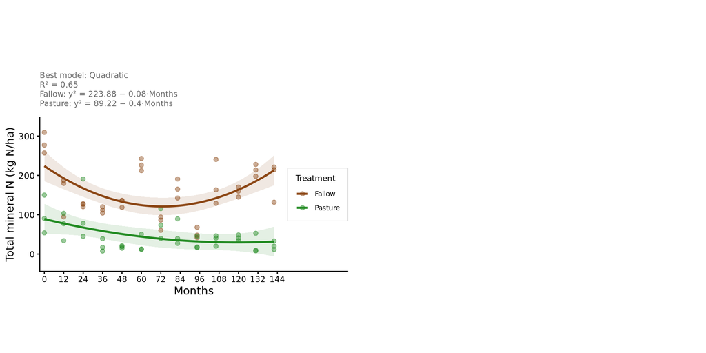

**AICc table**

| Response/Hypothesis | Model | K | n | R2 | AICc | Δi | ωi | Evid. ratio | Model Formula |
| --- | --- | --- | --- | --- | --- | --- | --- | --- | --- |
| tot_min_n_ha | Quadratic | 7 | 78 | 0.65 | 832.1 | 0.0 | 1 | 1.00 | months² × treatment |
|  | Square Root | 5 | 78 | 0.57 | 843.3 | 11.2 | 0 | 276.92 | sqrt(months) × treatment |
|  | Linear | 5 | 78 | 0.55 | 847.2 | 15.1 | 0 | 1902.91 | months × treatment |

**Model checks (click to show/hide)**

```
 ============================================================
 Response: tot_min_n_ha | Best model: Quadratic
============================================================
```

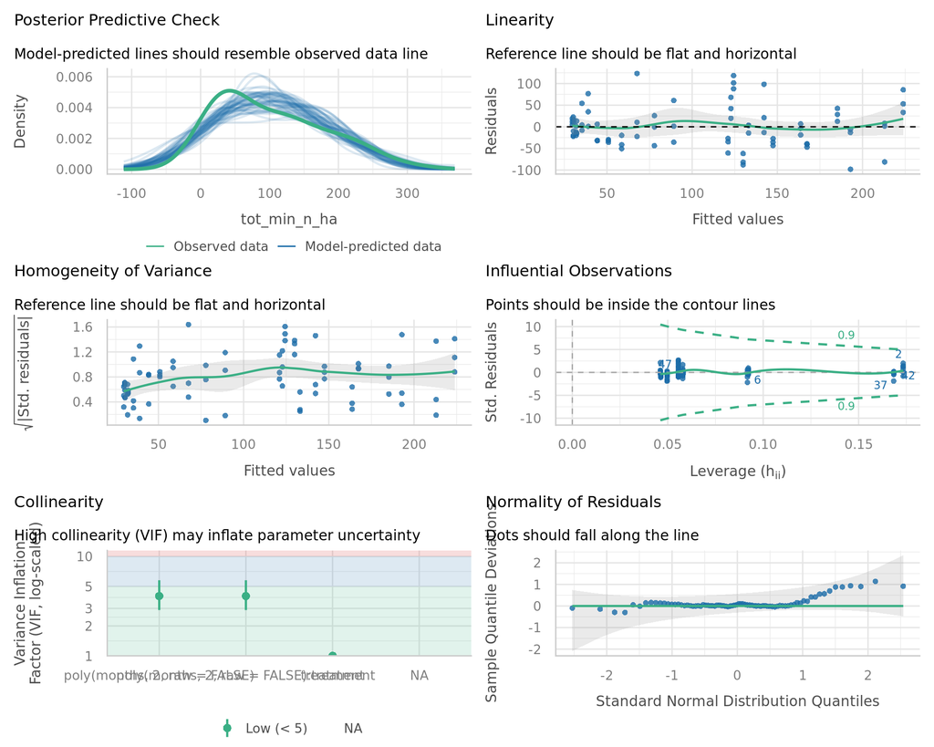

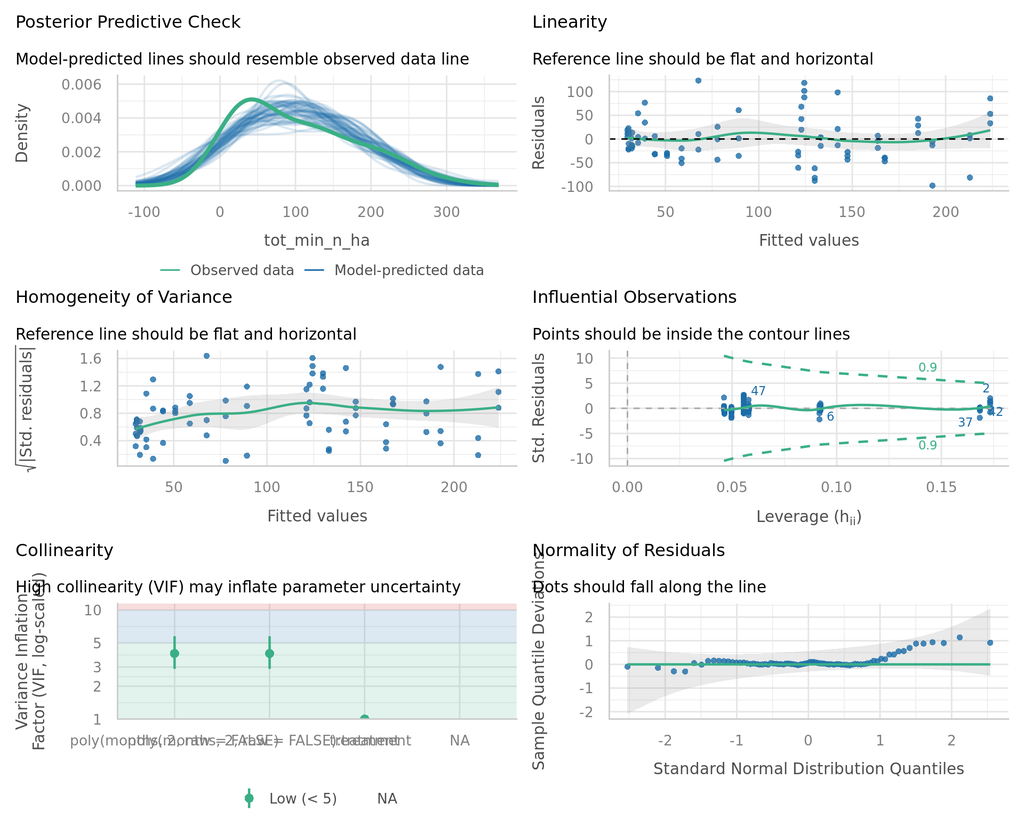

**Best model summaries (click to show/hide)**

```
======================================================================
  Response variable: tot_min_n_ha
  Best model:        Quadratic
======================================================================


Call:
lm(formula = f, data = d)

Residuals:
    Min      1Q  Median      3Q     Max
-98.225 -31.012  -2.111  19.494 123.261

Coefficients:
                                               Estimate Std. Error t value
(Intercept)                                     158.997      7.561  21.029
poly(months, 2, raw = FALSE)1                   -26.219     66.776  -0.393
poly(months, 2, raw = FALSE)2                   298.209     66.776   4.466
treatmentPasture                               -111.522     10.693 -10.430
poly(months, 2, raw = FALSE)1:treatmentPasture -130.960     94.436  -1.387
poly(months, 2, raw = FALSE)2:treatmentPasture -233.298     94.436  -2.470
                                               Pr(>|t|)
(Intercept)                                     < 2e-16 ***
poly(months, 2, raw = FALSE)1                    0.6957
poly(months, 2, raw = FALSE)2                  2.90e-05 ***
treatmentPasture                               4.84e-16 ***
poly(months, 2, raw = FALSE)1:treatmentPasture   0.1698
poly(months, 2, raw = FALSE)2:treatmentPasture   0.0159 *
---
Signif. codes:  0 '***' 0.001 '**' 0.01 '*' 0.05 '.' 0.1 ' ' 1

Residual standard error: 47.22 on 72 degrees of freedom
Multiple R-squared:  0.6528,    Adjusted R-squared:  0.6287
F-statistic: 27.07 on 5 and 72 DF,  p-value: 2.669e-15
```

**Export AICc tables to Excel**

# References

R Core Team (2022). R: A language and environment for statistical computing. R Foundation for Statistical Computing, Vienna, Austria.